# Answer

Ji-Dung Luo

## Variant Manipulation

In this exercise, we use vcf file downloaded from **1000 Genomes Project**. This file is available in **./data** folder. You can also download it here. Please use this file to answer the following questions.

1. Please loading the VCF file and find out how many variations and samples in it.

```r
library(VariantAnnotation)
vcf <- readVcf("./data/CEU.exon.2010_03.genotypes.vcf.gz")
vcf
```

```
## class: CollapsedVCF
## dim: 3489 90
## rowRanges(vcf):
##   GRanges with 5 metadata columns: paramRangeID, REF, ALT, QUAL, FILTER
## info(vcf):
##   DataFrame with 6 columns: DP, HM2, HM3, AA, AC, AN
## info(header(vcf)):
##        Number Type    Description
##    DP  1      Integer Total Depth
##    HM2 0      Flag    HapMap2 membership
##    HM3 0      Flag    HapMap3 membership
##    AA  1      String  Ancestral Allele, ftp://ftp.1000genomes.ebi.ac.uk...
##    AC  1      Integer total number of alternate alleles in called genot...
##    AN  1      Integer total number of alleles in called genotypes
## geno(vcf):
##   SimpleList of length 2: GT, DP
## geno(header(vcf)):
##       Number Type    Description
##    GT 1      String  Genotype
##    DP 1      Integer Read Depth from MOSAIK BAM
```

2. Please retrieve header lines of *Info* section.

```r
header_info <- info(header(vcf))
header_info
```

```
## DataFrame with 6 rows and 3 columns
##          Number        Type
##     <character> <character>
## DP            1     Integer
## HM2           0        Flag
## HM3           0        Flag
## AA            1      String
## AC            1     Integer
## AN            1     Integer
##                                                                                                               Description
##                                                                                                               <character>
## DP                                                                                                            Total Depth
## HM2                                                                                                    HapMap2 membership
## HM3                                                                                                    HapMap3 membership
## AA  Ancestral Allele, ftp://ftp.1000genomes.ebi.ac.uk/vol1/ftp/pilot_data/technical/reference/ancestral_alignments/README
## AC                                                                  total number of alternate alleles in called genotypes
## AN                                                                            total number of alleles in called genotypes
```

3. Please retrieve header lines of *Genotype* section.

```r
header_geno <- geno(header(vcf))
header_geno
```

```
## DataFrame with 2 rows and 3 columns
##         Number        Type                Description
##    <character> <character>                <character>
## GT           1      String                   Genotype
## DP           1     Integer Read Depth from MOSAIK BAM
```

4. Please extract variants in Chromosome 1

```r
rd <- rowRanges(vcf)
rd_chr1 <- rd[seqnames(rd)==1]
rd_chr1
```

```
## GRanges object with 344 ranges and 5 metadata columns:
##                   seqnames    ranges strand | paramRangeID            REF
##                      <Rle> <IRanges>  <Rle> |     <factor> <DNAStringSet>
##     1:1105366_T/C        1   1105366      * |         <NA>              T
##     1:1105411_G/A        1   1105411      * |         <NA>              G
##        rs61733845        1   1108138      * |         <NA>              C
##     1:1110240_T/A        1   1110240      * |         <NA>              T
##         rs1320571        1   1110294      * |         <NA>              G
##               ...      ...       ...    ... .          ...            ...
##         rs4659654        1 233449811      * |         <NA>              A
##        rs61740940        1 233487116      * |         <NA>              G
##           rs14326        1 233782146      * |         <NA>              A
##        rs35346732        1 233782155      * |         <NA>              G
##   1:245804116_A/C        1 245804116      * |         <NA>              A
##                                  ALT      QUAL      FILTER
##                   <DNAStringSetList> <numeric> <character>
##     1:1105366_T/C                  C      <NA>        PASS
##     1:1105411_G/A                  A      <NA>        PASS
##        rs61733845                  T      <NA>        PASS
##     1:1110240_T/A                  A      <NA>        PASS
##         rs1320571                  A      <NA>        PASS
##               ...                ...       ...         ...
##         rs4659654                  G      <NA>        PASS
##        rs61740940                  A      <NA>        PASS
##           rs14326                  G      <NA>        PASS
##        rs35346732                  A      <NA>        PASS
##   1:245804116_A/C                  C      <NA>        PASS
##   -------
##   seqinfo: 22 sequences from an unspecified genome; no seqlengths
```

5. Please draw a histgram for the depth of the varition in chromosome 1

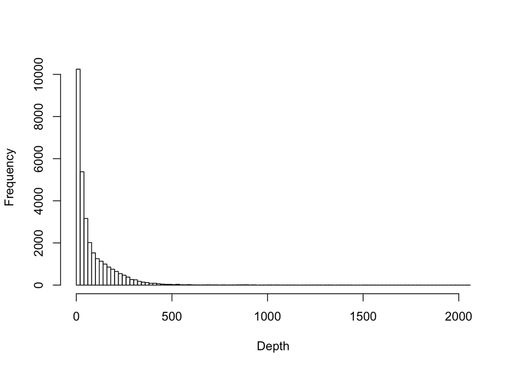

```r
dp_mat <- geno(vcf)$DP
dp_mat_chr1 <- dp_mat[rownames(dp_mat)%in%names(rd_chr1),]
hist(dp_mat_chr1,xlab="Depth",main="",breaks=100)
```

6. Please randomly select ten variants and evaluate the distribution of their genotypes in this population.

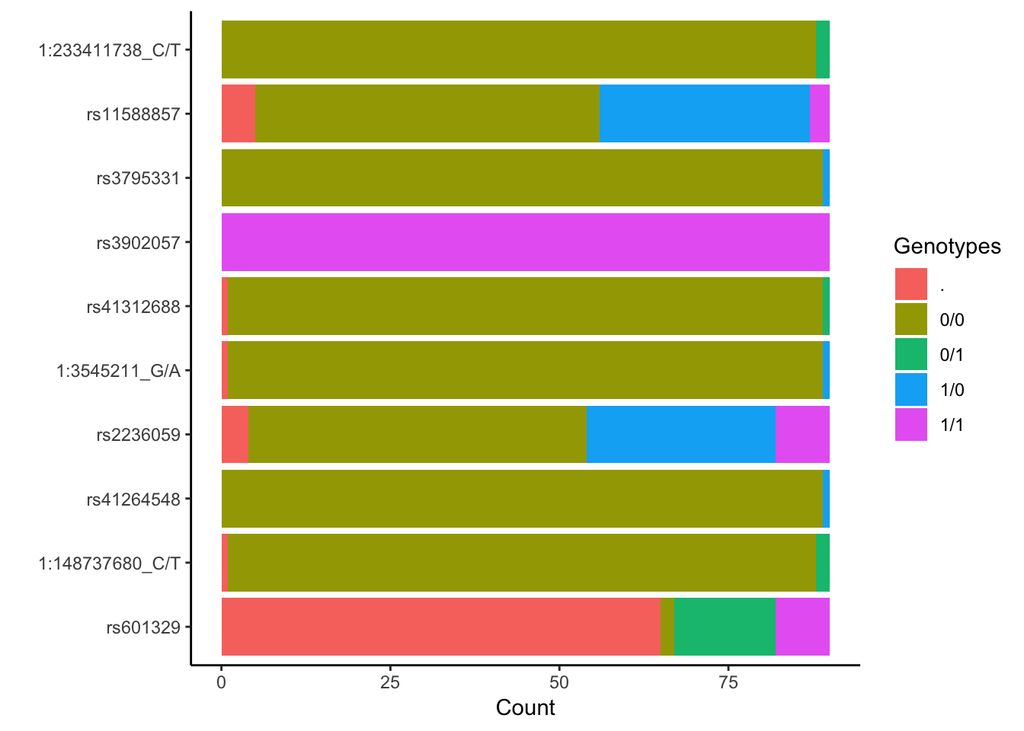

```r
randNum <- sample(1:length(rd_chr1),10)
var_id <- names(rd_chr1)[randNum]
gt_mat <- geno(vcf)$GT
gt_mat_chr1 <- gt_mat[rownames(gt_mat)%in%names(rd_chr1),]
gt_mat_sel <- gt_mat_chr1[rownames(gt_mat_chr1)%in%var_id,]
gt_type <- unique(as.vector(gt_mat_sel))
#
gt_count_sel <- NULL
for(i in 1:length(var_id)){
  var <- var_id[i]
  yd <- data.frame(Variant=rep(var,times=length(gt_type)))
  for(j in 1:length(gt_type)){
    gt <- gt_type[j]
    yd$GT[j] <- gt
    yd$count[j] <- length(which(gt_mat_sel[rownames(gt_mat_sel)==var,]==gt))
  }
  gt_count_sel <- rbind(gt_count_sel,yd)
}
#
library(ggplot2)
ggplot(gt_count_sel,aes(x=Variant,y=count,fill=GT))+
  geom_bar(stat='identity',position = position_stack(reverse = TRUE))+
  labs(x="",y="Count",fill="Genotypes")+theme_classic()+coord_flip()
```

7. Please select variants in chromosome 1 according to the following criteria:  
   **no-call(genotype==“.”) in less than 10 samples**  
   **depth<20 in less than 10 samples**  
   **PASS the filter (In this VCF, every variant is passed the filter)**

```r
var_dp <- rownames(dp_mat_chr1[!rowSums(dp_mat_chr1<=20)>=10,])
var_gt <- rownames(gt_mat_chr1[!rowSums(gt_mat_chr1==".")>=10,])
rd_chr1_sel <- rd_chr1[names(rd_chr1)%in%var_dp&names(rd_chr1)%in%var_gt&rd_chr1$FILTER=="PASS"]
rd_chr1_sel
```

```
## GRanges object with 38 ranges and 5 metadata columns:
##                   seqnames    ranges strand | paramRangeID            REF
##                      <Rle> <IRanges>  <Rle> |     <factor> <DNAStringSet>
##        rs35490896        1  35975172      * |         <NA>              G
##    1:50383354_G/A        1  50383354      * |         <NA>              G
##        rs41289414        1  61326636      * |         <NA>              C
##         rs2236059        1  61642371      * |         <NA>              G
##        rs41286716        1  66610658      * |         <NA>              C
##               ...      ...       ...    ... .          ...            ...
##   1:224122247_C/T        1 224122247      * |         <NA>              C
##   1:227838925_C/T        1 227838925      * |         <NA>              C
##         rs3811473        1 227839316      * |         <NA>              T
##         rs3811474        1 227839555      * |         <NA>              A
##   1:233411738_C/T        1 233411738      * |         <NA>              C
##                                  ALT      QUAL      FILTER
##                   <DNAStringSetList> <numeric> <character>
##        rs35490896                  A      <NA>        PASS
##    1:50383354_G/A                  A      <NA>        PASS
##        rs41289414                  T      <NA>        PASS
##         rs2236059                  A      <NA>        PASS
##        rs41286716                  A      <NA>        PASS
##               ...                ...       ...         ...
##   1:224122247_C/T                  T      <NA>        PASS
##   1:227838925_C/T                  T      <NA>        PASS
##         rs3811473                  G      <NA>        PASS
##         rs3811474                  G      <NA>        PASS
##   1:233411738_C/T                  T      <NA>        PASS
##   -------
##   seqinfo: 22 sequences from an unspecified genome; no seqlengths
```

8. Predict amino acid changes for the variations selected in #7  
   *This vcf is based onb hg18*.

```r
library(BSgenome.Hsapiens.UCSC.hg18)
library(TxDb.Hsapiens.UCSC.hg18.knownGene)
txdb <- TxDb.Hsapiens.UCSC.hg18.knownGene
seqlevelsStyle(txdb) <- "NCBI"
seqlevelsStyle(Hsapiens) <- "NCBI"
#
coding <- predictCoding(vcf, txdb, seqSource=Hsapiens)
```

[output not shown]

[output cut: 111 more lines]

```r
coding_sel <- coding[names(coding)%in%names(rd_chr1_sel)]
coding_sel
```

```
## GRanges object with 94 ranges and 17 metadata columns:
##                   seqnames    ranges strand | paramRangeID            REF
##                      <Rle> <IRanges>  <Rle> |     <factor> <DNAStringSet>
##        rs35490896        1  35975172      - |         <NA>              G
##        rs35490896        1  35975172      - |         <NA>              G
##    1:50383354_G/A        1  50383354      + |         <NA>              G
##    1:50383354_G/A        1  50383354      + |         <NA>              G
##    1:50383354_G/A        1  50383354      + |         <NA>              G
##               ...      ...       ...    ... .          ...            ...
##         rs3811474        1 227839555      + |         <NA>              A
##   1:233411738_C/T        1 233411738      - |         <NA>              C
##   1:233411738_C/T        1 233411738      - |         <NA>              C
##   1:233411738_C/T        1 233411738      - |         <NA>              C
##   1:233411738_C/T        1 233411738      - |         <NA>              C
##                                  ALT      QUAL      FILTER      varAllele
##                   <DNAStringSetList> <numeric> <character> <DNAStringSet>
##        rs35490896                  A      <NA>        PASS              T
##        rs35490896                  A      <NA>        PASS              T
##    1:50383354_G/A                  A      <NA>        PASS              A
##    1:50383354_G/A                  A      <NA>        PASS              A
##    1:50383354_G/A                  A      <NA>        PASS              A
##               ...                ...       ...         ...            ...
##         rs3811474                  G      <NA>        PASS              G
##   1:233411738_C/T                  T      <NA>        PASS              A
##   1:233411738_C/T                  T      <NA>        PASS              A
##   1:233411738_C/T                  T      <NA>        PASS              A
##   1:233411738_C/T                  T      <NA>        PASS              A
##                      CDSLOC    PROTEINLOC   QUERYID        TXID
##                   <IRanges> <IntegerList> <integer> <character>
##        rs35490896      3839          1280        51        4143
##        rs35490896      3647          1216        51        4144
##    1:50383354_G/A       157            53        81        1074
##    1:50383354_G/A       148            50        81        1075
##    1:50383354_G/A       199            67        81        1076
##               ...       ...           ...       ...         ...
##         rs3811474      2572           858       333        3163
##   1:233411738_C/T      3119          1040       337        6508
##   1:233411738_C/T      2861           954       337        6509
##   1:233411738_C/T      2861           954       337        6510
##   1:233411738_C/T      2162           721       337        6511
```

[output cut: 13 more lines]

```
##                         VARCODON         REFAA         VARAA
##                   <DNAStringSet> <AAStringSet> <AAStringSet>
##        rs35490896            TTA             S             L
##        rs35490896            TTA             S             L
##    1:50383354_G/A            ATC             V             I
##    1:50383354_G/A            ATC             V             I
##    1:50383354_G/A            ATC             V             I
##               ...            ...           ...           ...
##         rs3811474            GAA             K             E
##   1:233411738_C/T            CAG             R             Q
##   1:233411738_C/T            CAG             R             Q
##   1:233411738_C/T            CAG             R             Q
##   1:233411738_C/T            CAG             R             Q
##   -------
##   seqinfo: 22 sequences from an unspecified genome; no seqlengths
```

9. Please convert the results of #8 into a table including the following construction.

```r
int_tab <- data.frame(VarID=names(coding_sel),
                      chromosome=seqnames(coding_sel),
                      start=as.vector(start(coding_sel)),
                      end=as.vector(unlist(end(coding_sel))),
                      strand=as.vector(strand(coding_sel)),
                      Ref=as.vector(coding_sel$REF),
                      Alt=as.vector(unlist(coding_sel$ALT)),
                      Consequence=coding_sel$CONSEQUENCE,
                      EntrezID=coding_sel$GENEID,
                      TxID=coding_sel$TXID,
                      Codon=paste0("c.",coding_sel$CDSLOC,as.vector(coding_sel$REF),">",as.vector(unlist(coding_sel$ALT))),
                      aaChange=paste0("p.",as.vector(coding_sel$REFAA),coding_sel$PROTEINLOC,as.vector(unlist(coding_sel$VARAA))))
# library(DT)
# datatable(int_tab)
write.table(int_tab,"selected_variations_annotated_chr1.txt",row.names = FALSE,sep="\t",quote=FALSE)
names(int_tab)
```

```
##  [1] "VarID"       "chromosome"  "start"       "end"         "strand"
##  [6] "Ref"         "Alt"         "Consequence" "EntrezID"    "TxID"
## [11] "Codon"       "aaChange"
```

```r
head(int_tab)
```

```
##            VarID chromosome    start      end strand Ref Alt   Consequence
## 1     rs35490896          1 35975172 35975172      -   G   A nonsynonymous
## 2     rs35490896          1 35975172 35975172      -   G   A nonsynonymous
## 3 1:50383354_G/A          1 50383354 50383354      +   G   A nonsynonymous
## 4 1:50383354_G/A          1 50383354 50383354      +   G   A nonsynonymous
## 5 1:50383354_G/A          1 50383354 50383354      +   G   A nonsynonymous
## 6 1:50383354_G/A          1 50383354 50383354      +   G   A nonsynonymous
##   EntrezID TxID     Codon aaChange
## 1    63967 4143 c.3839G>A p.S1280L
## 2    63967 4144 c.3647G>A p.S1216L
## 3     1996 1074  c.157G>A   p.V53I
## 4     1996 1075  c.148G>A   p.V50I
## 5     1996 1076  c.199G>A   p.V67I
## 6     1996 1077  c.148G>A   p.V50I
```

10. Please demonstrate the proportion of variant types (consequence) in each sample with a bar chart.

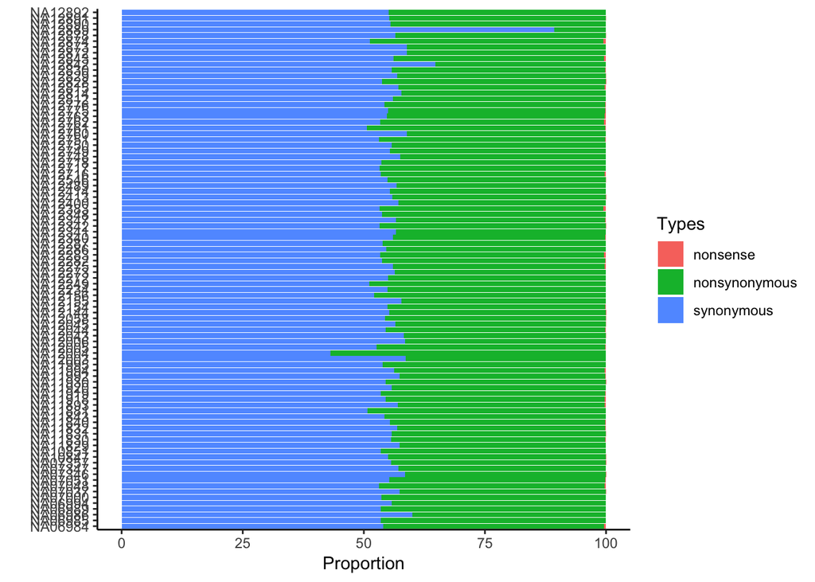

```r
sampleID <- samples(header(vcf))
count_tab <- NULL
for(k in 1:length(sampleID)){
  samID <- sampleID[k]
  var_dp <- rownames(dp_mat)[dp_mat[,k]>=20]
  var_gt <- rownames(gt_mat)[!gt_mat[,k]=="."&!gt_mat[,k]=="0/0"]
  var_sel <- names(coding)[names(coding)%in%var_dp&names(coding)%in%var_gt]
  #
  yd <- data.frame(sample_id=rep(samID,times=length(var_sel)),
                   var_id=var_sel,
                   consequence=coding$CONSEQUENCE[names(coding)%in%var_sel])
  count_tab <- rbind(count_tab,yd)
}
tbl <- table(count_tab$sample_id,count_tab$consequence)
proc_tbl <- (tbl/rowSums(tbl))*100
melt_proc <- data.frame(sample_id=rep(rownames(proc_tbl),times=3),
                        var_type=c(rep("nonsense",times=length(sampleID)),
                                   rep("nonsynonymous",times=length(sampleID)),
                                   rep("synonymous",times=length(sampleID))),
                        count=c(proc_tbl[,1],proc_tbl[,2],proc_tbl[,3]))
ggplot(melt_proc,aes(x=sample_id,y=count,fill=var_type))+
  geom_bar(stat='identity',position = position_stack(reverse = FALSE))+
  labs(x="",y="Proportion",fill="Types")+
  coord_flip()+theme_classic()
```